# Analyse du coefficient de condition de la truite en Occitanie

OFB - DR Bretagne

Le 05 mars 2023

# 1 Initialisation du projet

## 1.1 Paramétrages

Le présent document est paramétrable en choisissant les champs de la rubrique `params` de l’en-tête du document R Markdown.

On paramètre aussi la visibilité du code et des différents messages retournés lors de son exécution.

## 1.2 Chargement des packages

```r
library(aspe) # traitement des données ASPE
library(aspeQual) # mise en qualité des données ASPE
library(tidyverse) # mise en forme des données
library(mapview) # cartes interactives
library(sf) # analyse spatiale
library(ggridges) # graphiques (surcouche de ggplot2)
library(flextable) # affichage de tables bien présentées
```

## 1.3 Chargement des données

La fonction `misc_nom_dernier_fichier()` du package `aspe` renvoie le nom du fichier le plus récent dont le nom contient le *pattern* spécifié.

```r
# retrieve most recent data files
rdata_tables <-
  misc_nom_dernier_fichier(repertoire = "../../../../raw_data/rdata",
                           pattern = "^tables")

rdata_mei <-
  misc_nom_dernier_fichier(repertoire = "../../../../raw_data/rdata",
                           pattern = "^mei")
# load them
load(rdata_tables)
load(rdata_mei)
```

# 2 Jointures et sélection

On met en correspondance les identifiants des stations, popints de prélèvements, opération, etc. A ce stade le jeu de données est national sans filtre de période.

```r
# passerelle de correspondance des identifiants entre tables
passerelle <- mef_creer_passerelle()

passerelle %>%
  mutate_all(as.character) %>%
  head() %>%
  flextable::flextable() %>%
  set_caption("Quelques lignes de la table de correspondance entre les identifiants des stations (sta_id, pas toujours renseigné), points de prélèvement (pop_id), opération (ope_id), prélèvement individuel (pre_id) et lot (lop_id).")
```

Table 1: Quelques lignes de la table de correspondance entre les identifiants des stations (sta_id, pas toujours renseigné), points de prélèvement (pop_id), opération (ope_id), prélèvement individuel (pre_id) et lot (lop_id).

| sta_id | pop_id | ope_id | pre_id | lop_id |
| --- | --- | --- | --- | --- |
| 22814 | 77947 | 31437 | 58197 | 3643233 |
|  | 99276 | 31694 | 60147 | 3755333 |
|  | 99321 | 32791 | 60512 | 3707747 |
|  | 99321 | 32791 | 60513 | 3707802 |
|  | 99274 | 31680 | 60360 | 3754167 |
|  | 99274 | 31680 | 60361 | 3753911 |

# 3 Sélection de la région

Liste des départements de la région (donnée intégrée dans le package COGiter).

```r
# départements de la région
mes_depts <- COGiter::departements %>%
  filter(REG == params$code_region) %>%
  pull(DEP) %>%
  as.character()
```

Départements retenus : 09, 11, 12, 30, 31, 32, 34, 46, 48, 65, 66, 81, 82`

On filtre le jeu de données national, sélectionne les variables d’intérêt, puis ajoute les infos département, code sandre etc.

```r
passerelle <- passerelle %>%
  mef_ajouter_dept() %>%
  filter(dept %in% mes_depts) %>% # filtrage des départements
  mef_ajouter_ope_date() %>%
  mef_ajouter_lots() %>%
  mef_ajouter_type_lot() %>%
  mef_ajouter_esp() %>%
  mef_ajouter_libelle() %>%
  select(sta_id:annee, dept, tyl_libelle, esp_code_alternatif, pop_libelle) %>%
  distinct()
```

```r
passerelle %>%
  head() %>%
  mutate_if(is.integer, as.character) %>%
  mutate(ope_date = as.Date(ope_date),
         annee = as.character(annee)) %>%
  flextable::flextable() %>%
  colformat_int(j = 3, big.mark = " ") %>%
  colformat_double(j = 4:5, digits = 3) %>%
  align(j = 1:5, align = "center", part = "all") %>%
  set_table_properties(layout = "autofit", width = .9) %>%
  set_caption("Exemple de lignes du tableau de données intermédiaire.")
```

Table 2: Exemple de lignes du tableau de données intermédiaire.

| sta_id | pop_id | ope_id | pre_id | lop_id | dept | ope_date | annee | tyl_libelle | esp_code_alternatif | pop_libelle |
| --- | --- | --- | --- | --- | --- | --- | --- | --- | --- | --- |
| 22814 | 77947 | 31437 | 58197 | 3643233 | 11 | 2013-10-24 | 2013 | S/L | GOU | Le Lampy à Alzonne |
|  | 99724 | 35533 | 65981 | 4020608 | 34 | 1998-07-02 | 1998 | N | TRF | La Lergue à Pégairolles-de-l'Escalette |
|  | 99371 | 34334 | 63318 | 3963503 | 48 | 1988-09-14 | 1988 | G | GOU | Le Lot à Esclanèdes |
| 22620 | 77397 | 35384 | 67807 | 4163693 | 66 | 2015-09-09 | 2015 | S/L | CHE | TET A NEFIACH |
| 23142 | 78977 | 34023 | 65740 | 4031599 | 34 | 1997-06-05 | 1997 | N | ABL | Le Lez à Castelnau-le-Lez |
|  | 99649 | 35431 | 65564 | 4102343 | 30 | 2002-08-02 | 2002 | S/L | BLN | Le Gardon à Sanilhac-Sagriès |

# 4 Mesures individuelles

## 4.1 Constitution du tableau

Ajout des mesures individuelles.

```r
mei <- passerelle %>%
  mef_ajouter_mei() %>%
  filter(mei_mesure_reelle == "t",
         tyl_libelle == "N",
         !is.na(mei_taille)) %>%
  mutate(mei_poids_bis = ifelse(test = is.na(mei_poids),
                            yes = mei_poids_estime,
                            no = mei_poids)) %>%
  filter(!is.na(mei_poids_bis))
```

Sélection des truites, calcul de Fulton et des classes de taille sur les individus. Les individus avec les coefficients de condition hors norme (intervalle [0.6, 1.6], paramétrable dans l’en-tête du présent document à la rubrique `params`) sont écartés du jeu de données.

```r
data_ind <- mei %>%
  filter(esp_code_alternatif == params$code_espece,
         mei_poids_bis > 0) %>%
  mutate(
    fulton = 100 * mei_poids_bis / (mei_taille / 10) ^ 3,
    classe_taille = cut(
      mei_taille,
      breaks = params$limites_classes_taille,
      labels = params$etiquettes_classes_taille
    )
  ) %>%
  filter(fulton > params$fulton_mini,
         fulton < params$fulton_maxi) %>%
  left_join(y = point_prelevement %>%
              select(pop_id,
                     pop_altitude)) %>%
  select(
    pop_id,
    pop_libelle,
    dept,
    pop_altitude,
    ope_date,
    annee,
    mei_id,
    mei_taille,
    mei_poids_bis,
    fulton,
    classe_taille
  )
```

```r
data_ind %>%
  head() %>%
  mutate_if(is.integer, as.character) %>%
  mutate(ope_date = as.Date(ope_date),
         annee = as.character(annee)) %>%
  flextable::flextable() %>%
  colformat_int(j = c(4, 9), big.mark = " ") %>%
  colformat_double(j = 10, digits = 3) %>%
#  align(j = 1:5, align = "center", part = "all") %>%
  set_table_properties(layout = "autofit", width = .9) %>%
  set_caption("Exemple de lignes du tableau de mesures individuelles. Dans la variable `mei_poids_bis`, les vareuls manquantes de `mei_poids` sont remplacées mar `mei_poids_estime` s'il s'agit de lots `N` et que `mei_mesure_reelle` est taggé `t`. C'est `mei_poids_bis` qui sert au calcul de coefficient de condition.")
```

Table 3: Exemple de lignes du tableau de mesures individuelles. Dans la variable `mei_poids_bis`, les vareuls manquantes de `mei_poids` sont remplacées mar `mei_poids_estime` s’il s’agit de lots `N` et que `mei_mesure_reelle` est taggé `t`. C’est `mei_poids_bis` qui sert au calcul de coefficient de condition.

| pop_id | pop_libelle | dept | pop_altitude | ope_date | annee | mei_id | mei_taille | mei_poids_bis | fulton | classe_taille |
| --- | --- | --- | --- | --- | --- | --- | --- | --- | --- | --- |
| 99724 | La Lergue à Pégairolles-de-l'Escalette | 34 | 290 | 1998-07-02 | 1998 | 5708486 | 80 | 6 | 1.172 | <100mm |
| 99758 | Le Chassezac à Prévenchères | 48 | 1028 | 1999-09-08 | 1999 | 5982893 | 185 | 65 | 1.027 | 150-200mm |
| 99695 | L'Orb à Avène | 34 | 370 | 1991-06-19 | 1991 | 5724782 | 159 | 45 | 1.119 | 150-200mm |
| 99782 | Le Carol (Querol) à Porta | 66 | 1427 | 1994-08-29 | 1994 | 6116165 | 83 | 7 | 1.224 | <100mm |
| 99724 | La Lergue à Pégairolles-de-l'Escalette | 34 | 290 | 1998-07-02 | 1998 | 5650292 | 80 | 6 | 1.172 | <100mm |
| 99688 | L'Orb à Ceilhes-et-Rocozels | 34 | 450 | 1989-09-26 | 1989 | 6164714 | 170 | 50 | 1.018 | 150-200mm |

## 4.2 Résumé

### 4.2.1 Les années d’échantillonnage

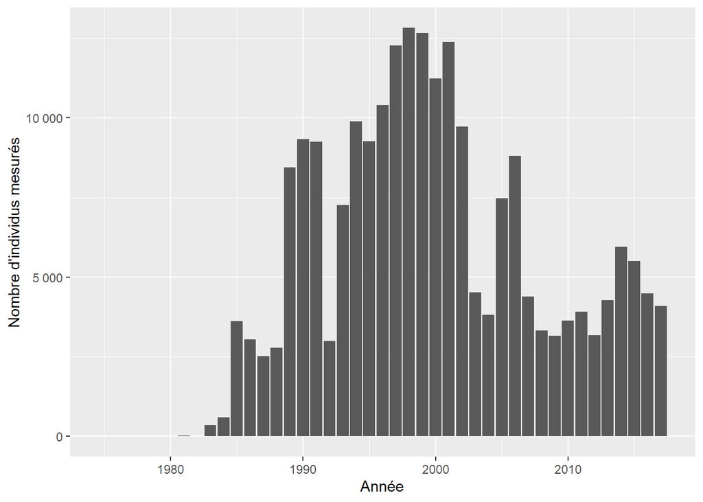

Figure 1: Nombre d’individus mesurés chaque année.

```r
resume_data <- data_ind %>%
  group_by(annee) %>%
    summarise(n_indiv = n_distinct(mei_id),
              n_points = n_distinct(pop_id))

ggplot(data = resume_data,
       aes(x = annee,
           y = n_indiv)) +
  geom_bar(stat = "identity") +
  labs(x = "Année",
       y = "Nombre d'individus mesurés") +
  scale_y_continuous(labels = scales::comma_format(big.mark = ' '))
```

### 4.2.2 Les longueurs

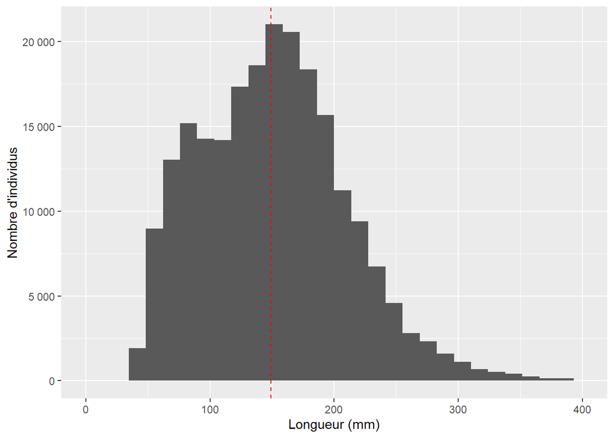

Figure 2: Distribution des longueurs avec la médiane en pointillés rouges.

```r
ggplot(data = data_ind,
       aes(x = mei_taille)) +
  geom_histogram() +
#  geom_density(bins = 50)+
  scale_x_continuous(limits = c(0, 400)) +
  scale_y_continuous(labels = scales::comma_format(big.mark = ' ')) +
  geom_vline(xintercept = median(data_ind$mei_taille, na.rm = TRUE),
             col = "red",
             linetype = "dashed") +
  labs(x = "Longueur (mm)",
       y = "Nombre d'individus")
```

> Difficile de distinguer les 0+.

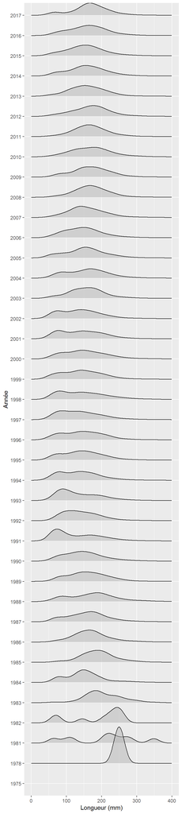

Figure 3: Variations interannuelle de la distribution des tailles des individus mesurés (densités de probabilité ; se lit comme un histogramme qui serait lissé).

```r
ggplot(data = data_ind,
       aes(x = mei_taille, y = as.factor(annee))) +
  ggridges::geom_density_ridges(quantile_lines = FALSE,
                                alpha = 0.5) +
  scale_x_continuous(limits = c(0, 400)) +
  labs(x = "Longueur (mm)",
       y = "Année")
```

### 4.2.3 Les coefficients de condition

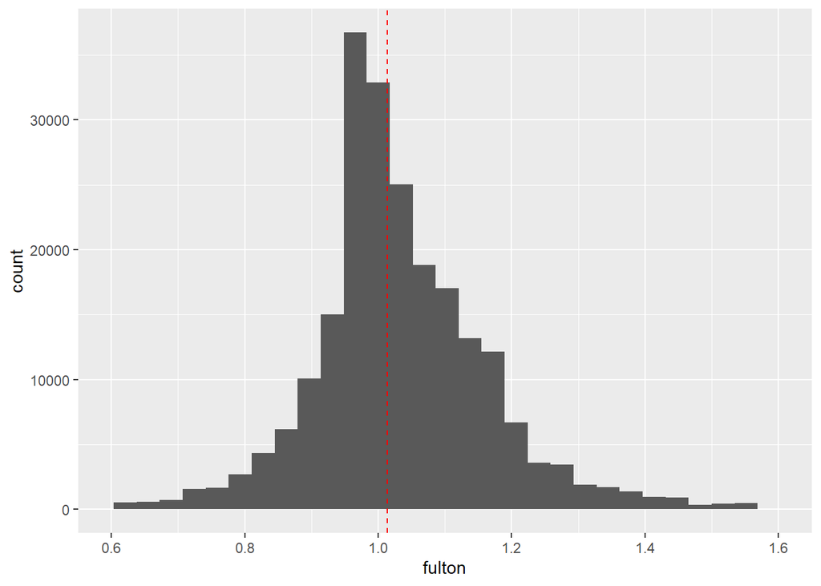

Figure 4: Distribution des coefficients de condition avec la médiane en pointillés rouges.

```r
ggplot(data = data_ind,
       aes(x = fulton)) +
  geom_histogram() +
  scale_x_continuous(limits = c(params$fulton_mini, params$fulton_maxi)) +
  geom_vline(xintercept = median(data_ind$fulton, na.rm = TRUE),
             col = "red",
             linetype = "dashed")
```

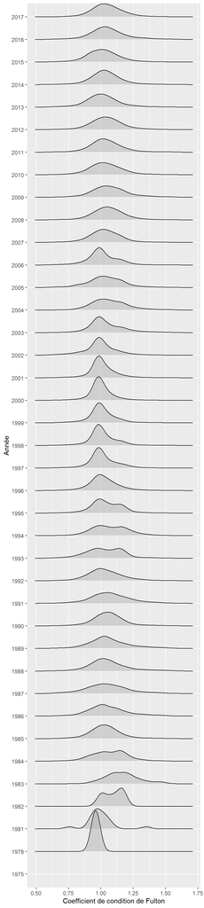

Figure 5: Variations interannuelle de la distribution des coefficients de condition (densités de probabilité ; se lit comme un histogramme qui serait lissé).

```r
ggplot(data = data_ind,
       aes(x = fulton,
           y = as.factor(annee))) +
  ggridges::stat_density_ridges(quantile_lines = FALSE,
                                alpha = 0.5) +
  labs(x = "Coefficient de condition de Fulton",
       y = "Année")
```

# 5 Effet année

## 5.1 Sur toute la région

Calcul, pour chaque combinaison année x classe_taille x département, du coefficient de condition médian.

```r
data_mediane_ope <- data_ind %>%
  group_by(annee, classe_taille, dept, pop_id) %>%
    summarise(fulton_median = median(fulton, na.rm = TRUE))
```

```r
data_mediane_ope %>%
  head() %>%
  mutate_if(is.integer, as.character) %>%
  mutate(annee = as.character(annee)) %>%
  flextable::flextable() %>%
  colformat_int(j = 3, big.mark = " ") %>%
  colformat_double(j = 5, digits = 3) %>%
  align(j = 1:5, align = "center", part = "all") %>%
  set_table_properties(layout = "autofit", width = .9) %>%
  set_caption("Exemple de lignes du tableau de données sur les Fulton médians par année, opération et classe de taille.")
```

Table 4: Exemple de lignes du tableau de données sur les Fulton médians par année, opération et classe de taille.

| annee | classe_taille | dept | pop_id | fulton_median |
| --- | --- | --- | --- | --- |
| 1975 | >250mm | 81 | 96616 | 0.945 |
| 1978 | 200-250mm | 81 | 96595 | 0.960 |
| 1981 | <100mm | 66 | 99770 | 1.009 |
| 1981 | <100mm | 66 | 99806 | 1.050 |
| 1981 | 100-150mm | 34 | 99740 | 1.350 |
| 1981 | 100-150mm | 66 | 99770 | 1.052 |

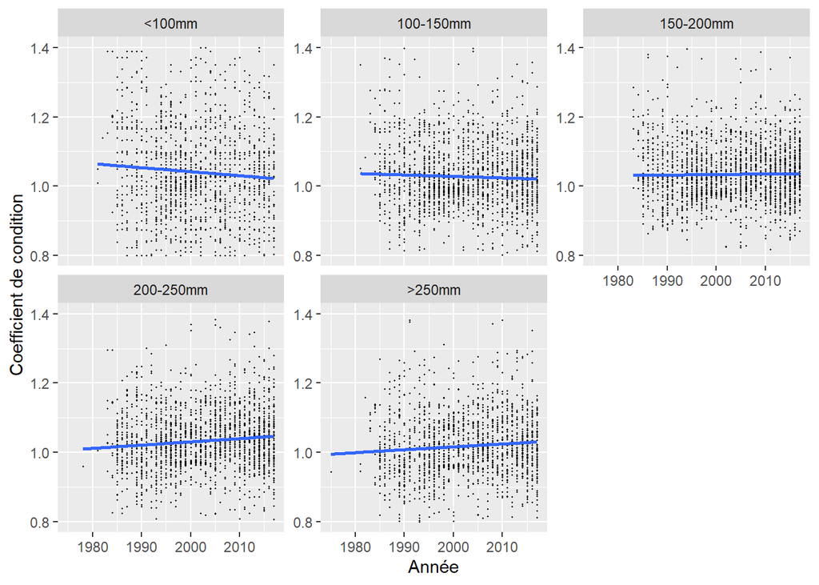

Figure 6: Pour chaque classe de taille, relation entre le coefficient de Fulton médian et l’année. Chaque point représente une opération.

```r
ggplot(data = data_mediane_ope,
       aes(x = annee,
           y = fulton_median)) +
  geom_point(size = 0.2) +
  geom_smooth(method = "lm", se = FALSE) +
  scale_y_continuous(limits = c(0.8, 1.4)) +
  #scale_x_continuous(limits = c(0, 700)) +
  facet_wrap(facets = vars(classe_taille),
             scales = "free_y") +
  labs(x = "Année",
       y = "Coefficient de condition")
```

## 5.2 Décliné par département

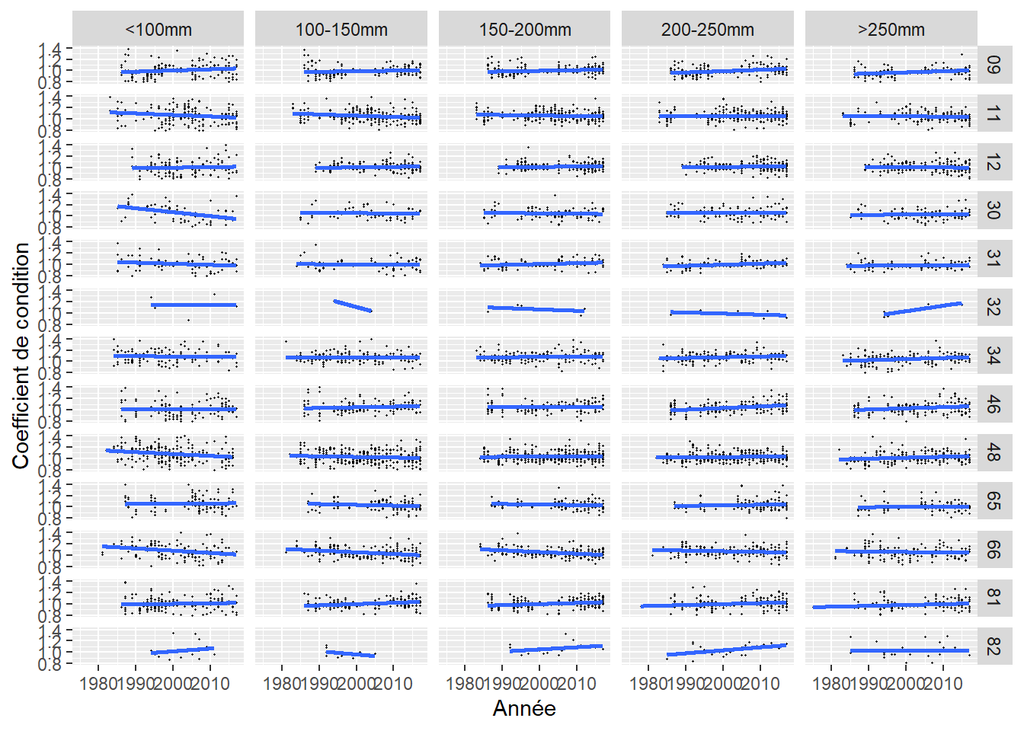

Figure 7: Pour chaque combinaison classe de taille x département, relation entre le coefficient de Fulton médian et l’année. Chaque point représente une opération.

```r
ggplot(data = data_mediane_ope,
       aes(x = annee,
           y = fulton_median)) +
  geom_point(size = 0.2) +
  geom_smooth(method = "lm", se = FALSE) +
  scale_y_continuous(limits = c(0.8, 1.4)) +
  facet_grid(cols = vars(classe_taille),
             rows = vars(dept),
             scales = "free_y") +
  labs(x = "Année",
       y = "Coefficient de condition")
```

# 6 Lien condition - altitude

## 6.1 Toutes tailles

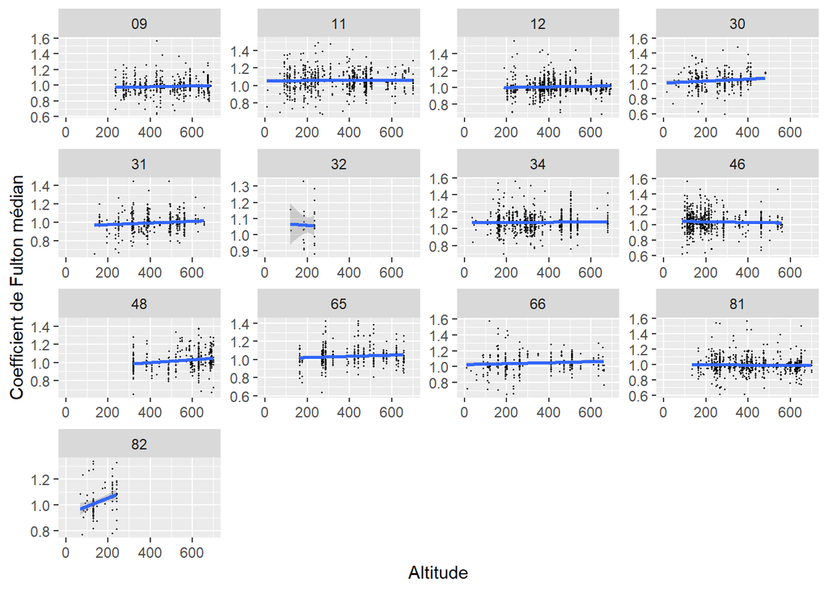

Figure 8: Pour chaque département, relation entre le coefficient de Fulton médian et l’altitude. Chaque point représente une opération.

```r
data_ind <- data_ind %>%
  filter(pop_altitude > 0)

data_mediane_an_ct_dept_alt <- data_ind %>%
  group_by(annee, dept, pop_id, pop_altitude, classe_taille) %>%
    summarise(fulton_median = median(fulton, na.rm = TRUE),
              altitude_mediane = median(pop_altitude, na.rm = TRUE)) %>%
  filter(fulton_median > params$fulton_mini,
         fulton_median < params$fulton_maxi)

ggplot(data = data_mediane_an_ct_dept_alt,
       aes(x = altitude_mediane,
           y = fulton_median)) +
  geom_point(size = 0.2) +
  geom_smooth(method = 'lm') +
  scale_x_continuous(limits = c(0, 700)) +
  facet_wrap(vars(dept), scale = "free") +
  labs(x = "Altitude",
       y = "Coefficient de Fulton médian")
```

## 6.2 Déclinaison par classe de taille

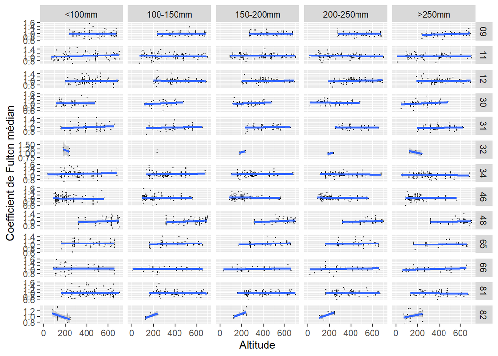

Figure 9: Pour chaque département et chaque classe de taille, relation entre le coefficient de Fulton médian et l’altitude. Chaque point représente une opération.

```r
ggplot(data = data_mediane_an_ct_dept_alt,
       aes(x = pop_altitude,
           y = fulton_median)) +
  geom_point(size = 0.2) +
  geom_smooth(method = 'lm') +
  scale_x_continuous(limits = c(0, 700)) +
  facet_grid(rows = vars(dept),
             cols = vars(classe_taille),
             scale = "free") +
  labs(x = "Altitude",
       y = "Coefficient de Fulton médian")
```

# 7 Essais de modélisation

On tente ici de tester de potentiels effets de l’année et de l’altitude sur le coefficient de condition.

## 7.1 Bivariée

### 7.1.1 Effet classe de taille

```r
data_ind %>%
  group_by(classe_taille) %>%
    summarise(n_sites = n_distinct(pop_id),
              n_indiv = n_distinct(mei_id),
              fulton_median = median(fulton, na.rm = TRUE),
              fulton_ecart_type = sd(fulton, na.rm = TRUE)) %>%
  flextable::flextable() %>%
  colformat_int(j = 3, big.mark = " ") %>%
  colformat_double(j = 4:5, digits = 3) %>%
  align(j = 1:5, align = "center", part = "all") %>%
  set_table_properties(layout = "autofit", width = .9) %>%
  set_caption("Table descriptive des valeurs du coefficient de condition, par classe de taille.")
```

Table 5: Table descriptive des valeurs du coefficient de condition, par classe de taille.

| classe_taille | n_sites | n_indiv | fulton_median | fulton_ecart_type |
| --- | --- | --- | --- | --- |
| <100mm | 685 | 49 915 | 1.027 | 0.175 |
| 100-150mm | 742 | 60 883 | 1.001 | 0.126 |
| 150-200mm | 759 | 64 488 | 1.016 | 0.107 |
| 200-250mm | 743 | 29 519 | 1.022 | 0.100 |
| >250mm | 622 | 11 157 | 1.000 | 0.105 |

Comparaisons de moyennes dans l’ensemble (ANOVA).

```r
anova1 <- aov(fulton_median ~ classe_taille, data = data_mediane_an_ct_dept_alt)

summary(anova1)
```

```
##                 Df Sum Sq Mean Sq F value   Pr(>F)
## classe_taille    4   0.49 0.12260   11.51 2.55e-09 ***
## Residuals     9846 104.90 0.01065
## ---
## Signif. codes:  0 '***' 0.001 '**' 0.01 '*' 0.05 '.' 0.1 ' ' 1
```

Il y a un effet classe de taille sur le Fulton moyen (`Pr(>F)` < 5%) => Test post_hoc pour voir quelles classes de taille diffèrent 2 à 2 avec un test de Tukey.

```r
tuk <- TukeyHSD(anova1)

tuk$classe_taille %>%
  as.data.frame() %>%
  mutate(sig = case_when(`p adj` < 0.001 ~ "***",
                         `p adj` < 0.01 ~ "**",
                         `p adj` < 0.05 ~ "*",
                         TRUE ~ ""))
```

```
##                             diff          lwr          upr        p adj sig
## 100-150mm-<100mm    -0.008441582 -0.017685630  0.000802465 9.259289e-02
## 150-200mm-<100mm    -0.001297333 -0.010354488  0.007759823 9.950765e-01
## 200-250mm-<100mm    -0.002991542 -0.012114420  0.006131337 8.989886e-01
## >250mm-<100mm       -0.020293316 -0.029942656 -0.010643975 9.835103e-08 ***
## 150-200mm-100-150mm  0.007144250 -0.001475073  0.015763572 1.576716e-01
## 200-250mm-100-150mm  0.005450041 -0.003238317  0.014138399 4.268676e-01
## >250mm-100-150mm    -0.011851733 -0.021091345 -0.002612122 4.269880e-03  **
## 200-250mm-150-200mm -0.001694209 -0.010183450  0.006795032 9.826313e-01
## >250mm-150-200mm    -0.018995983 -0.028048611 -0.009943355 1.060312e-07 ***
## >250mm-200-250mm    -0.017301774 -0.026420158 -0.008183390 2.287281e-06 ***
```

### 7.1.2 Effet année

```r
data <- data_ind %>%
  mutate(annee = as.character(annee)) %>%
  group_by(annee) %>%
    summarise(n_sites = n_distinct(pop_id),
              n_indiv = n_distinct(mei_id),
              fulton_mediane = median(fulton, na.rm = TRUE),
              fulton_ecart_type = sd(fulton, na.rm = TRUE))

data %>%
  flextable::flextable() %>%
  colformat_int(j = 1:3, big.mark = " ") %>%
  colformat_double(j = 4:5, digits = 3) %>%
  align(j = c(1, 4, 5), align = "center", part = "all") %>%
  set_table_properties(layout = "autofit", width = .9) %>%
  set_caption("Table descriptive des valeurs du coefficient de condition, par année.")
```

Table 6: Table descriptive des valeurs du coefficient de condition, par année.

| annee | n_sites | n_indiv | fulton_mediane | fulton_ecart_type |
| --- | --- | --- | --- | --- |
| 1975 | 1 | 1 | 0.945 |  |
| 1978 | 1 | 4 | 0.960 | 0.000 |
| 1981 | 4 | 18 | 0.976 | 0.115 |
| 1982 | 1 | 9 | 1.092 | 0.075 |
| 1983 | 3 | 82 | 1.185 | 0.155 |
| 1984 | 16 | 594 | 1.070 | 0.141 |
| 1985 | 42 | 3 615 | 1.028 | 0.127 |
| 1986 | 50 | 3 045 | 1.029 | 0.154 |
| 1987 | 48 | 2 376 | 1.045 | 0.166 |
| 1988 | 25 | 2 539 | 1.037 | 0.151 |
| 1989 | 70 | 8 448 | 1.043 | 0.158 |
| 1990 | 60 | 9 293 | 1.054 | 0.126 |
| 1991 | 46 | 8 776 | 1.063 | 0.150 |
| 1992 | 25 | 2 869 | 1.019 | 0.140 |
| 1993 | 56 | 6 481 | 1.029 | 0.139 |
| 1994 | 78 | 9 723 | 1.061 | 0.141 |
| 1995 | 78 | 9 165 | 1.026 | 0.120 |
| 1996 | 92 | 10 011 | 1.007 | 0.119 |
| 1997 | 100 | 11 843 | 0.989 | 0.110 |
| 1998 | 104 | 12 546 | 0.989 | 0.105 |
| 1999 | 105 | 12 365 | 0.994 | 0.113 |
| 2000 | 88 | 10 936 | 0.984 | 0.093 |
| 2001 | 94 | 11 962 | 0.990 | 0.101 |
| 2002 | 75 | 9 576 | 0.988 | 0.130 |
| 2003 | 66 | 4 121 | 1.016 | 0.143 |
| 2004 | 56 | 3 697 | 1.058 | 0.146 |
| 2005 | 112 | 7 147 | 1.040 | 0.147 |
| 2006 | 101 | 8 801 | 0.995 | 0.121 |
| 2007 | 78 | 4 388 | 1.027 | 0.128 |
| 2008 | 78 | 3 322 | 1.054 | 0.127 |
| 2009 | 74 | 3 164 | 1.061 | 0.149 |
| 2010 | 84 | 3 636 | 1.028 | 0.137 |
| 2011 | 88 | 3 907 | 1.028 | 0.132 |
| 2012 | 85 | 3 179 | 1.041 | 0.131 |
| 2013 | 107 | 4 280 | 1.007 | 0.133 |
| 2014 | 119 | 5 957 | 1.029 | 0.124 |
| 2015 | 122 | 5 501 | 1.012 | 0.127 |
| 2016 | 139 | 4 486 | 1.042 | 0.145 |
| 2017 | 122 | 4 099 | 1.043 | 0.125 |

```r
anova2 <- aov(fulton ~ as.factor(annee), data = data_ind)
summary(anova2)
```

```
##                      Df Sum Sq Mean Sq F value Pr(>F)
## as.factor(annee)     38    122   3.219   196.1 <2e-16 ***
## Residuals        215923   3544   0.016
## ---
## Signif. codes:  0 '***' 0.001 '**' 0.01 '*' 0.05 '.' 0.1 ' ' 1
```

```r
anova2
```

```
## Call:
##    aov(formula = fulton ~ as.factor(annee), data = data_ind)
##
## Terms:
##                 as.factor(annee) Residuals
## Sum of Squares           122.307  3543.803
## Deg. of Freedom               38    215923
##
## Residual standard error: 0.1281107
## Estimated effects may be unbalanced
```

Anova => Il y a des différences interannuelles dans les coefficients moyens.

Effet linéaire ? Régression simple

```r
lm1 <- lm(fulton_mediane ~ as.integer(annee), data = data)
summary(lm1)
```

```
##
## Call:
## lm(formula = fulton_mediane ~ as.integer(annee), data = data)
##
## Residuals:
##       Min        1Q    Median        3Q       Max
## -0.084269 -0.026404  0.000413  0.016158  0.156174
##
## Coefficients:
##                     Estimate Std. Error t value Pr(>|t|)
## (Intercept)        1.1702007  1.1485450   1.019    0.315
## as.integer(annee) -0.0000712  0.0005749  -0.124    0.902
##
## Residual standard error: 0.04139 on 37 degrees of freedom
## Multiple R-squared:  0.0004144,  Adjusted R-squared:  -0.0266
## F-statistic: 0.01534 on 1 and 37 DF,  p-value: 0.9021
```

On conclut qu’il y a des différences interannuelles significatives sur les coefficients moyens, mais pas de tendance temporelle linéaire.

### 7.1.3 Effet de l’altitude

```r
data <- data_ind %>%
  group_by(pop_id, pop_altitude) %>%
    summarise(pop_altitude = median(pop_altitude, na.rm = TRUE),
              fulton_mediane = median(fulton, na.rm = TRUE))
```

```r
modele <- lm(fulton_mediane ~ pop_altitude, data = data)
summary(modele)
```

```
##
## Call:
## lm(formula = fulton_mediane ~ pop_altitude, data = data)
##
## Residuals:
##      Min       1Q   Median       3Q      Max
## -0.36648 -0.04998 -0.01441  0.04624  0.48836
##
## Coefficients:
##               Estimate Std. Error t value Pr(>|t|)
## (Intercept)  1.016e+00  5.324e-03 190.898   <2e-16 ***
## pop_altitude 1.736e-05  8.702e-06   1.995   0.0463 *
## ---
## Signif. codes:  0 '***' 0.001 '**' 0.01 '*' 0.05 '.' 0.1 ' ' 1
##
## Residual standard error: 0.09153 on 910 degrees of freedom
## Multiple R-squared:  0.004355,   Adjusted R-squared:  0.00326
## F-statistic:  3.98 on 1 and 910 DF,  p-value: 0.04634
```

On a un léger effet simple altitude, avec une tendance à des poissons plus “trapus” en altitude.

## 7.2 Multiple

```r
data <- data_ind %>%
  group_by(pop_id, pop_altitude, classe_taille, annee) %>%
    summarise(pop_altitude = median(pop_altitude, na.rm = TRUE),
              fulton_mediane = median(fulton, na.rm = TRUE))
```

```r
mod1 <- lm(fulton_mediane~annee+pop_altitude+classe_taille,
           data = data)

summary(mod1)
```

```
##
## Call:
## lm(formula = fulton_mediane ~ annee + pop_altitude + classe_taille,
##     data = data)
##
## Residuals:
##      Min       1Q   Median       3Q      Max
## -0.42373 -0.05687 -0.01281  0.05390  0.53980
##
## Coefficients:
##                          Estimate Std. Error t value Pr(>|t|)
## (Intercept)             7.893e-01  2.266e-01   3.483 0.000498 ***
## annee                   1.213e-04  1.132e-04   1.071 0.283999
## pop_altitude            7.434e-06  2.862e-06   2.597 0.009411 **
## classe_taille100-150mm -8.774e-03  3.391e-03  -2.587 0.009688 **
## classe_taille150-200mm -1.630e-03  3.325e-03  -0.490 0.624117
## classe_taille200-250mm -3.131e-03  3.348e-03  -0.935 0.349631
## classe_taille>250mm    -1.989e-02  3.546e-03  -5.609 2.09e-08 ***
## ---
## Signif. codes:  0 '***' 0.001 '**' 0.01 '*' 0.05 '.' 0.1 ' ' 1
##
## Residual standard error: 0.1032 on 9844 degrees of freedom
## Multiple R-squared:  0.005449,   Adjusted R-squared:  0.004843
## F-statistic: 8.989 on 6 and 9844 DF,  p-value: 8.114e-10
```

=> Les effets altitude et classe de taille sont confirmés, mais toujours pas d’effet année.

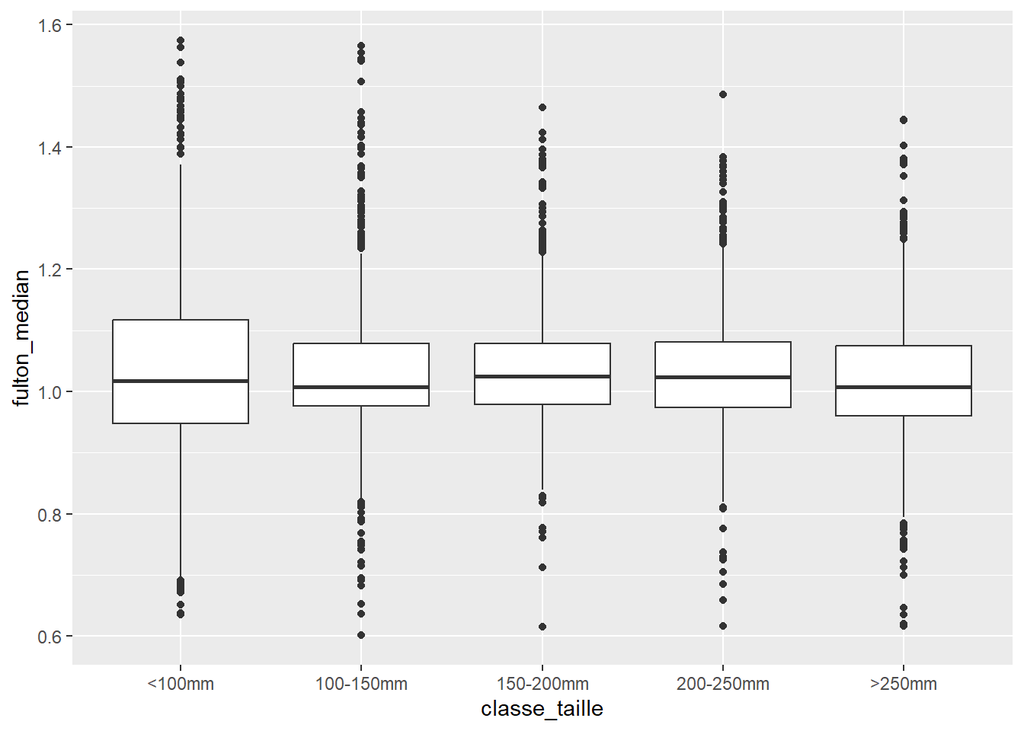

```r
ggplot(data = data_mediane_an_ct_dept_alt,
       aes(x = classe_taille,
           y = fulton_median)) +
  geom_boxplot()
```

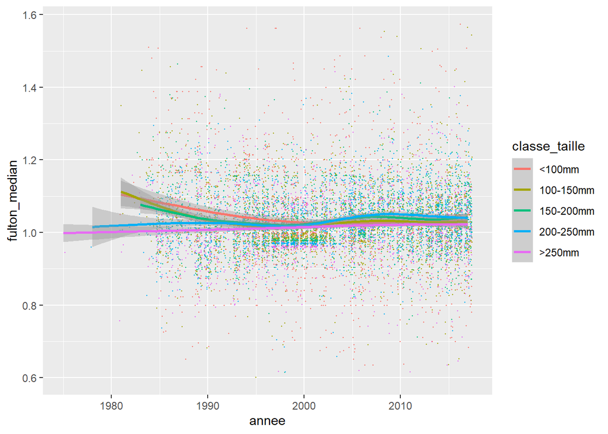

```r
ggplot(data = data_mediane_an_ct_dept_alt,
       aes(x = annee,
           y = fulton_median,
           col = classe_taille)) +
  geom_jitter(size = 0.2) +
  geom_smooth()
```